# Analise de Series Temporais - Trabalho 1

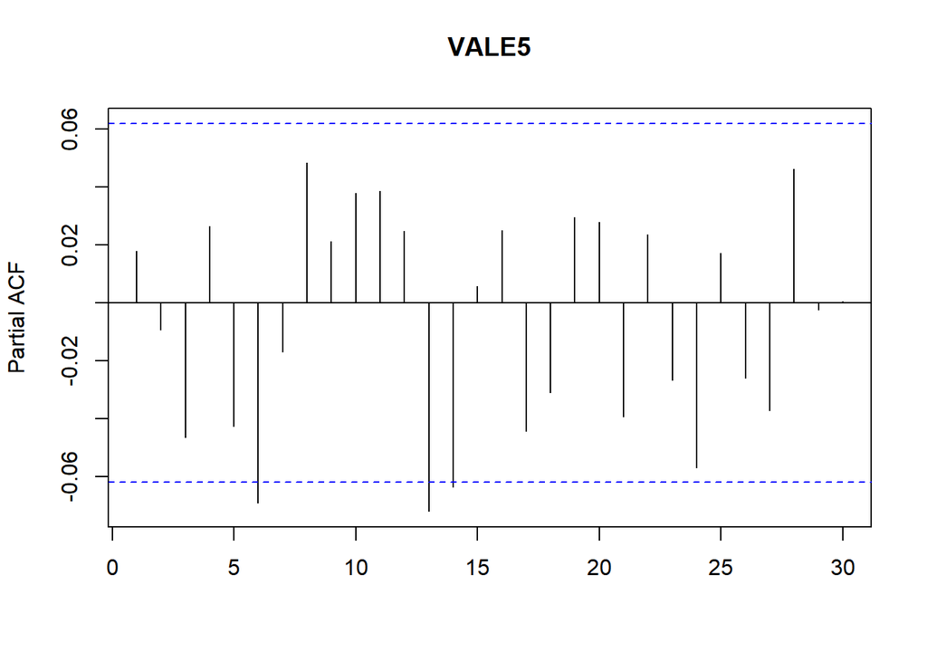

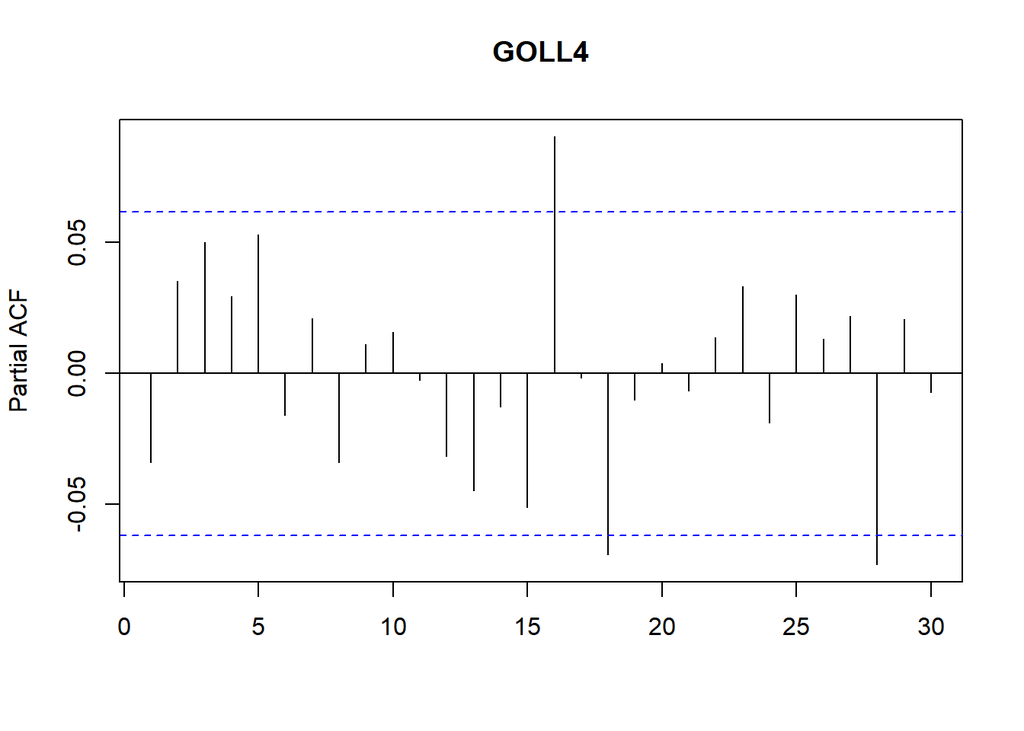

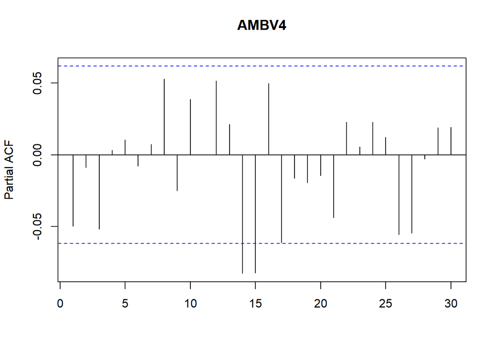

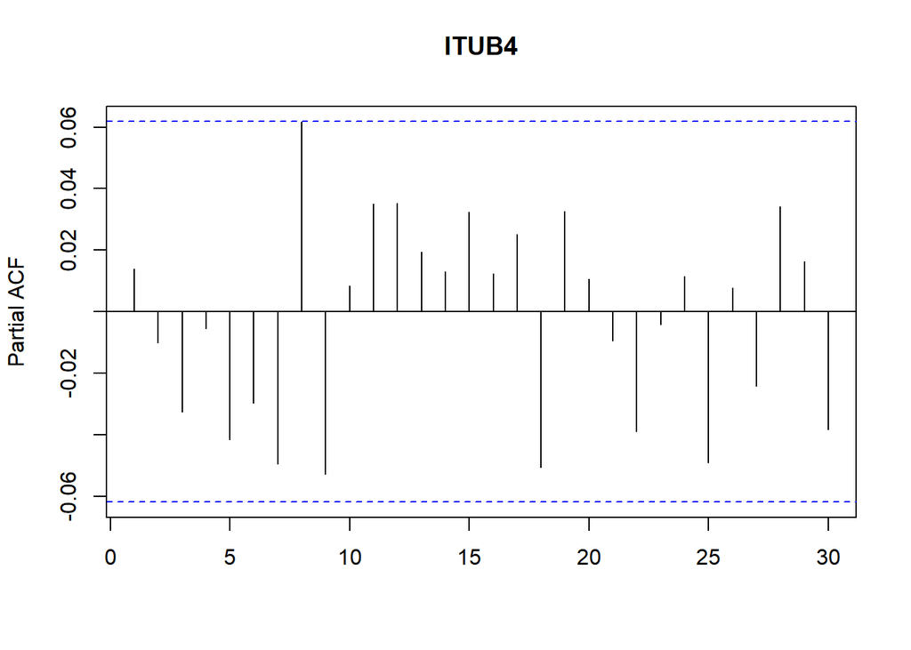

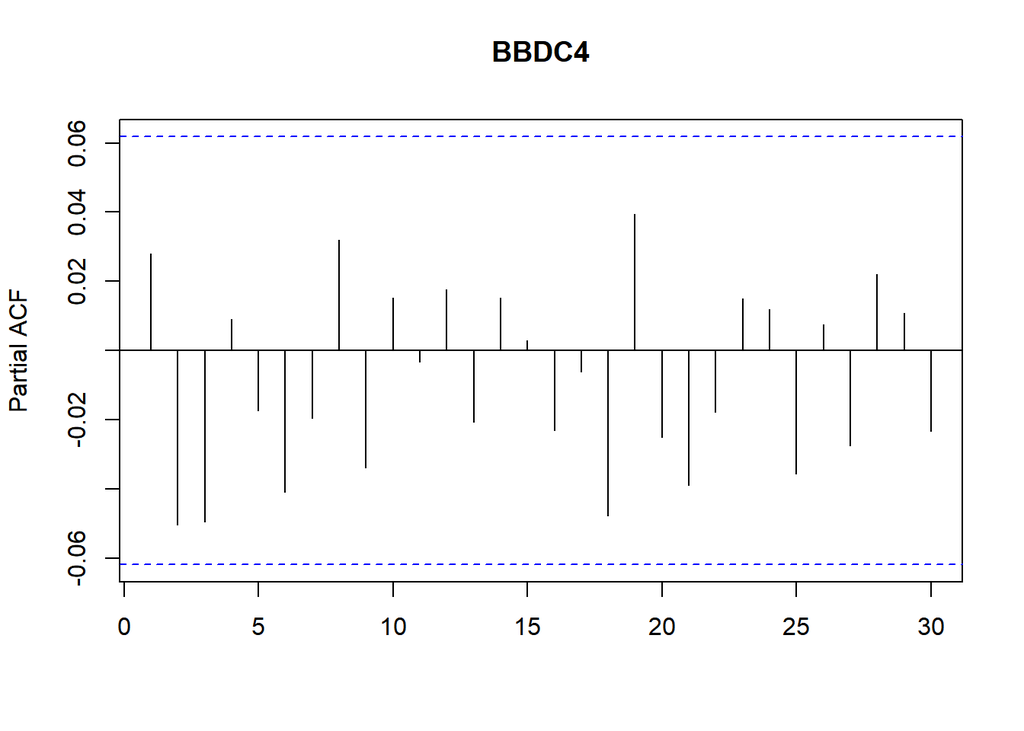

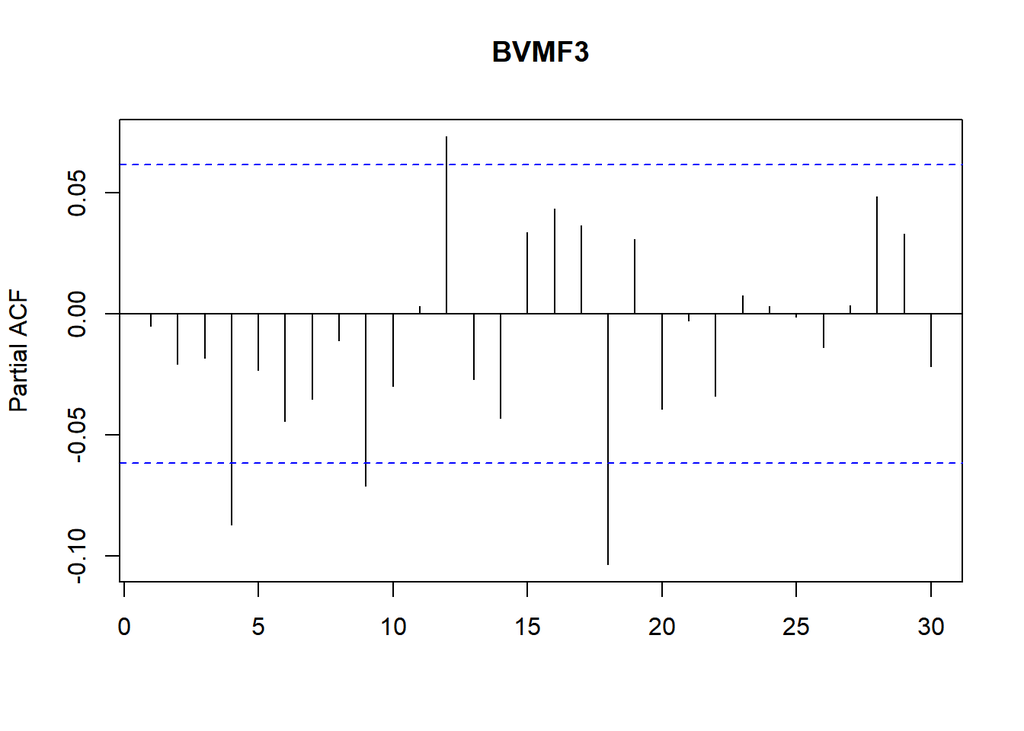

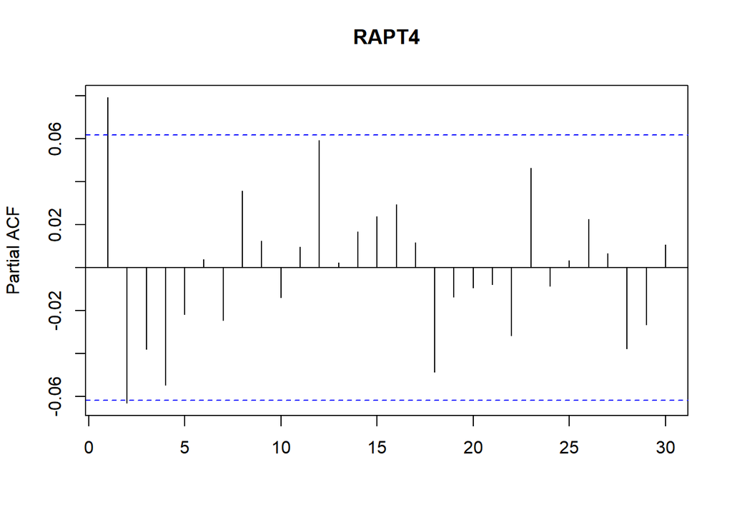

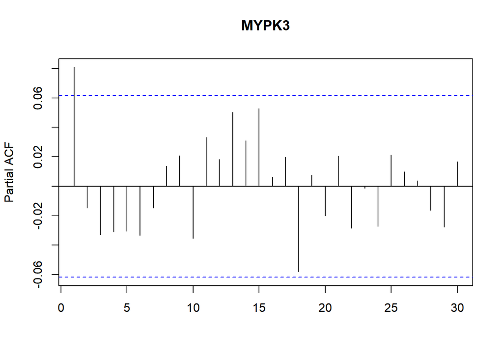

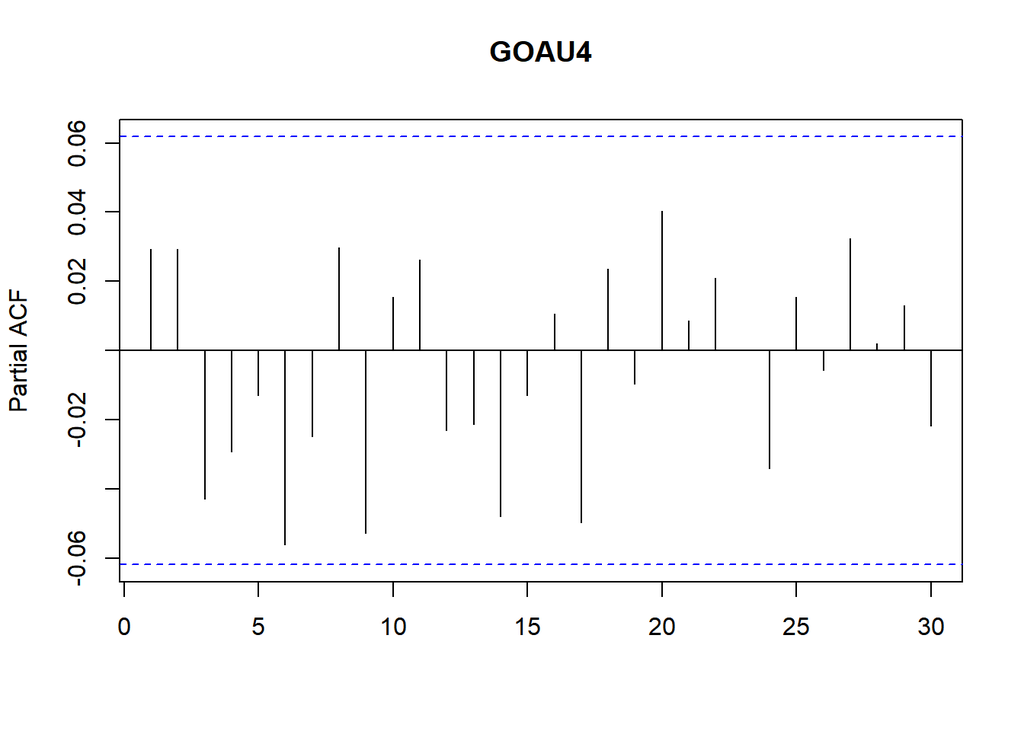

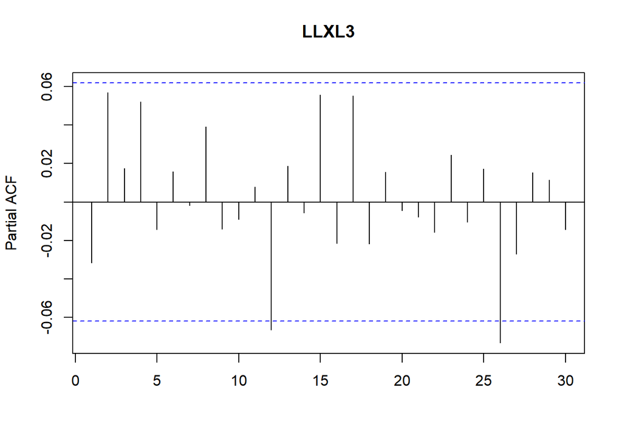

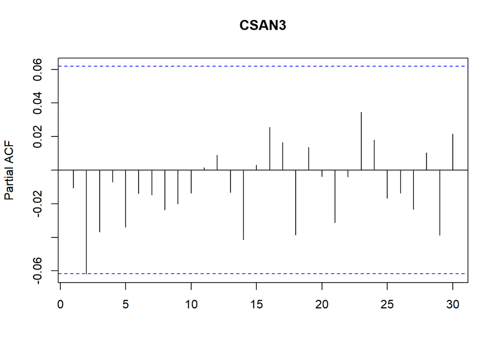

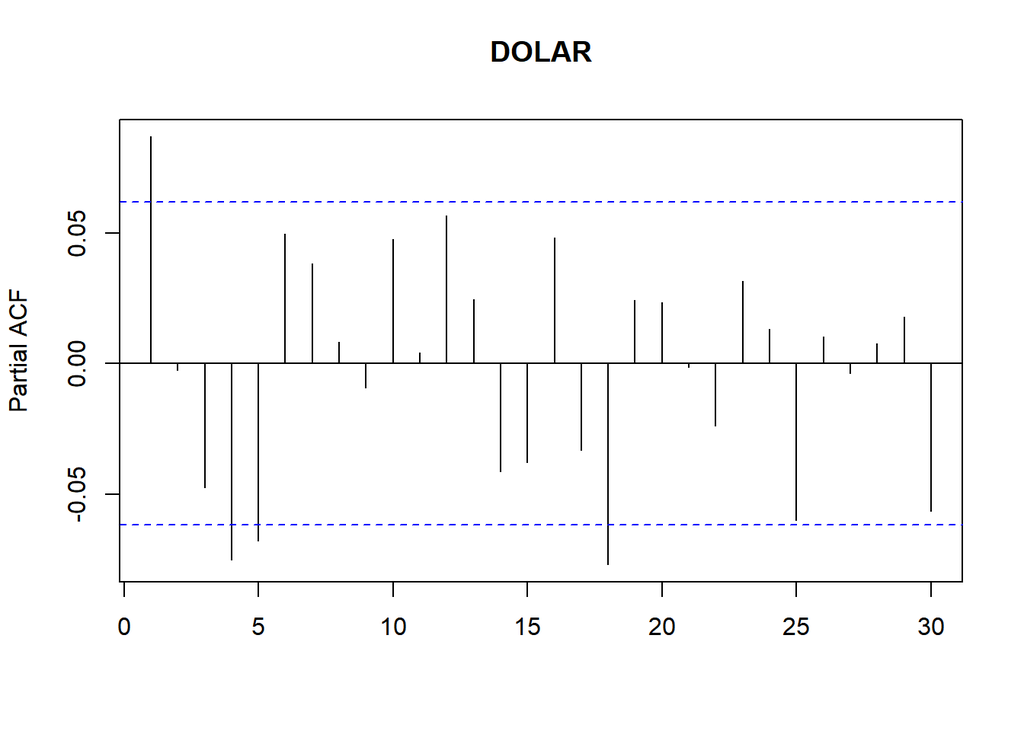

```r
for (col in 1:ncol(Serie_Dados.LN)) {
  pacf(Serie_Dados.LN[,col], main = names(Serie_Dados.LN[col]), xlab = "")
}
```

2- Para cada um dos processos abaixo gere 200 observações. Faça um gráfico da série, ACF e PACF. Comente os resultados.

Definindo uma semente para os numeros aleatorios serem sempre os mesmos:

```r
set.seed(1234)
```

4. Série aleatória, observações iid da distribuição N(0,1)

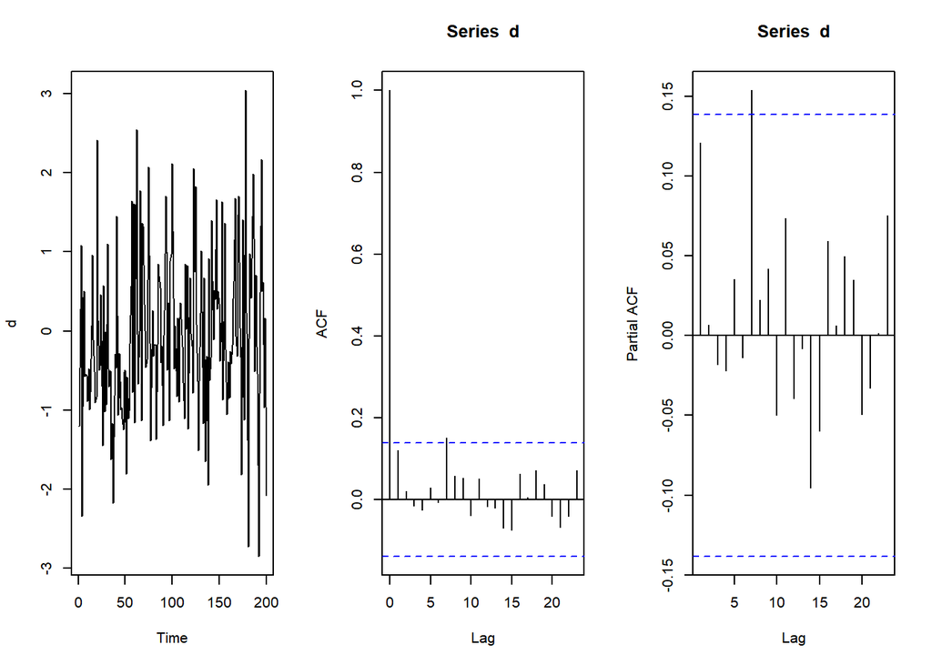

```r
#x.iid = data.frame(t = x[2:200],
#                 t_1 = x[1:199])
#x.iid
#x.iid.mod = lm(t~t_1,data = x.iid)
#summary(x.iid.mod)
#plot(x.iid.mod)
#acf(x.iid)
#pacf(x.iid)

par(mfrow = c(1, 3))

d <- ts(rnorm(200, 0, 1)) #ts: time series
plot(d)
acf(d)
pacf(d)
```

A serie é estacionária, mas por ser iid tem a PACF igual a 0

5. Série com tendência estocástica,

Neste caso o coeficiente tem que ser menor que 1 para rodar, então ar = 0.99999

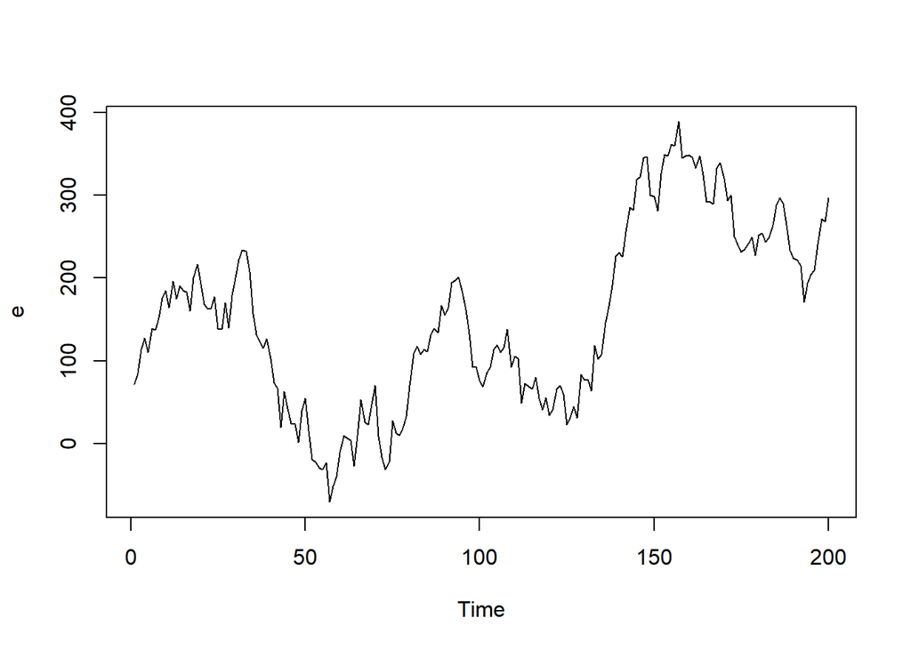

```r
e <- arima.sim(model = list(ar= 0.99999), n=200, innov = rnorm(200,1,25))
plot(e)
```

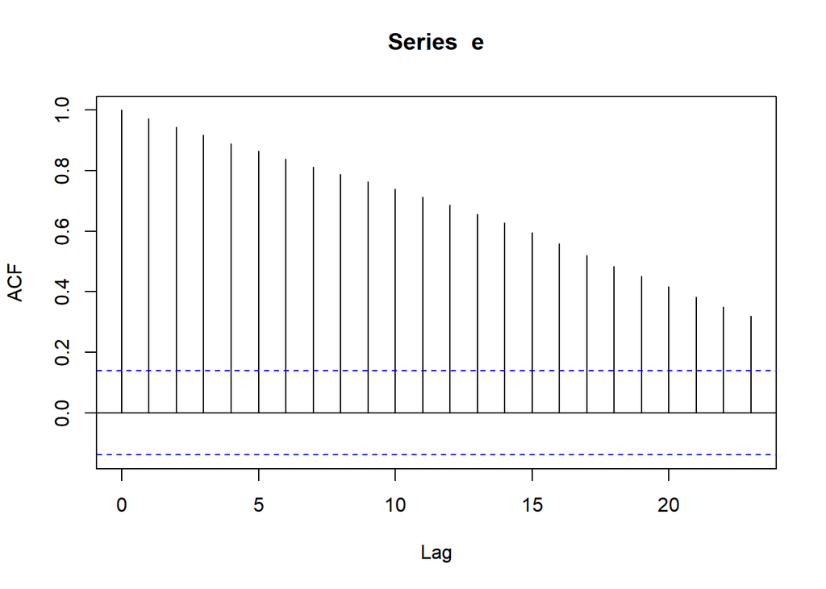

```r
acf(e)
```

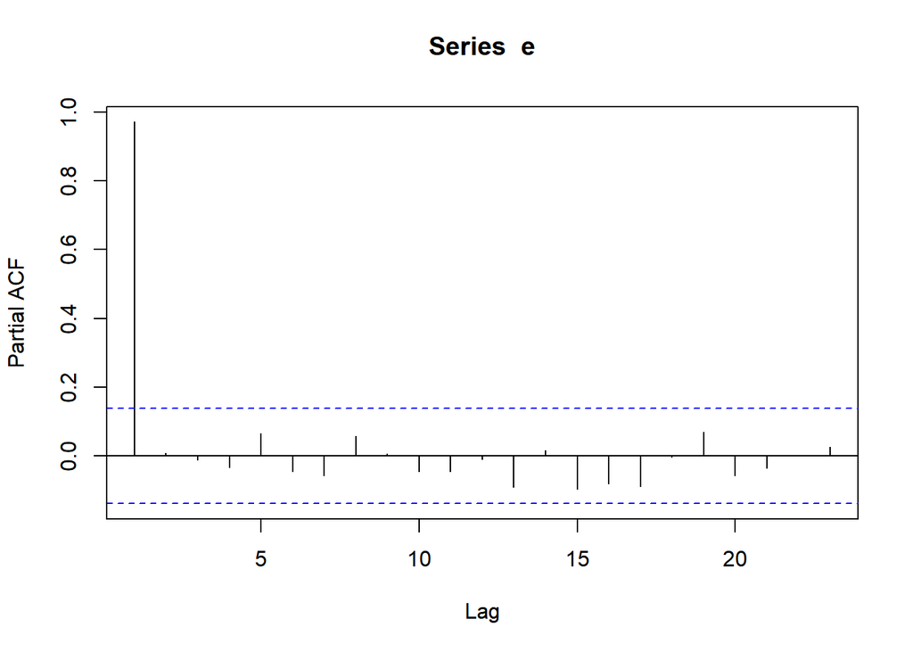

```r
pacf(e)
```

A série não é estacionaria

6. Serie com correlação de curto-prazo,

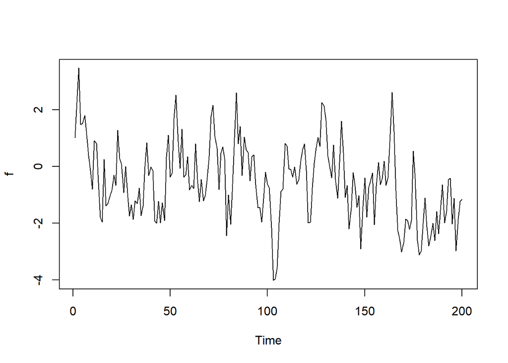

```r
f <- arima.sim(model = list(ar = 0.7), n = 200, innov = rnorm(200, 0, 1))
plot(f)
```

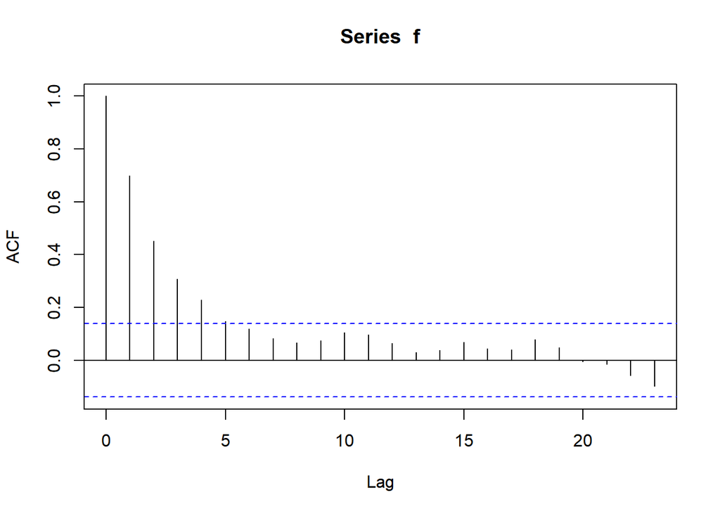

```r
acf(f)
```

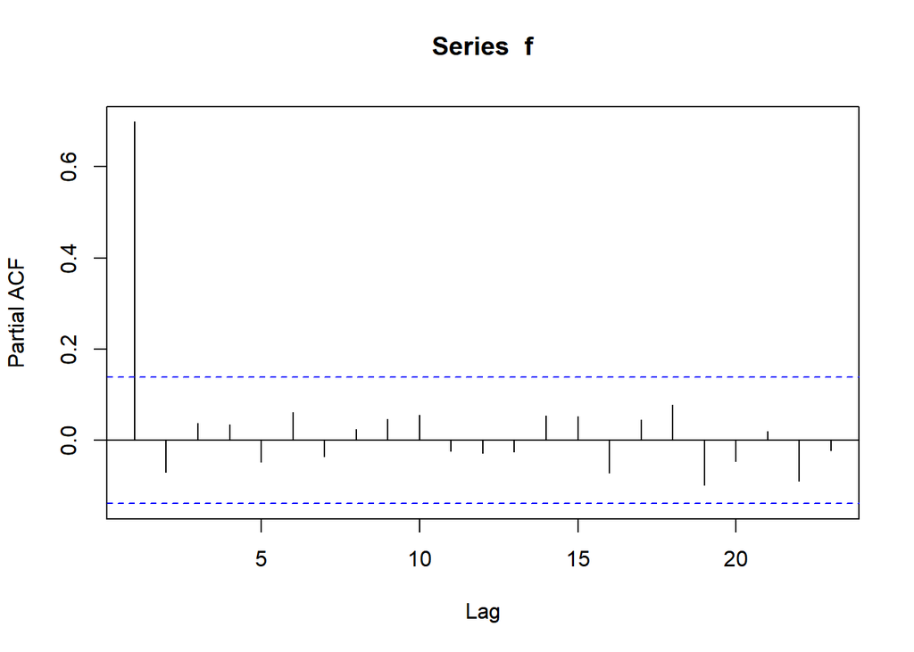

```r
pacf(f)
```

A série é estacionária, ACF com decaimento e grafico de pacf com pico em 1

7. Série com correlações negativas

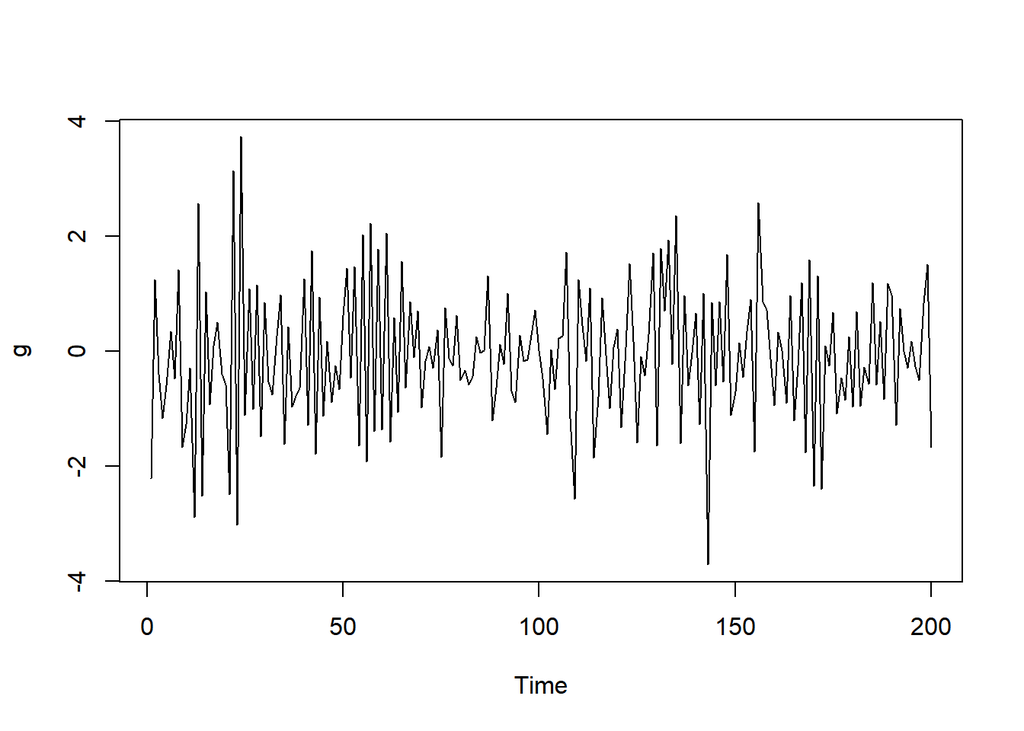

```r
g <- arima.sim(model = list(ar = -0.7), n = 200, innov = rnorm(200, 0, 1))
plot(g)
```

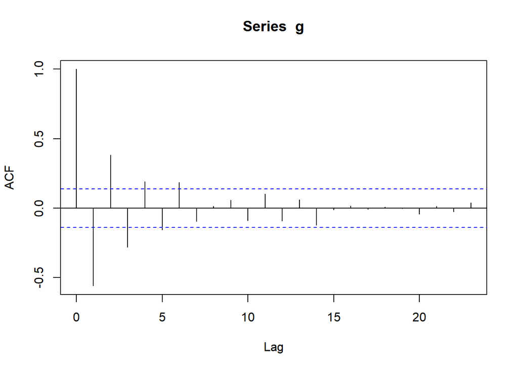

```r
acf(g)
```

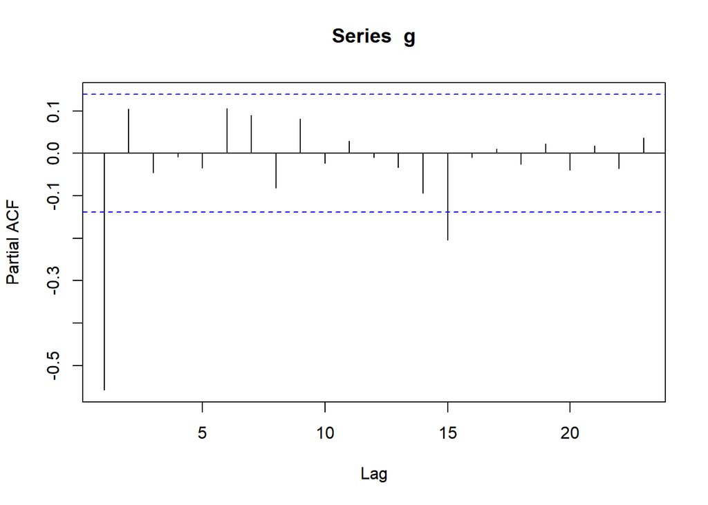

```r
pacf(g)
```

A série é estacionária, acf com decaimento oscilando, pacf pico em 1

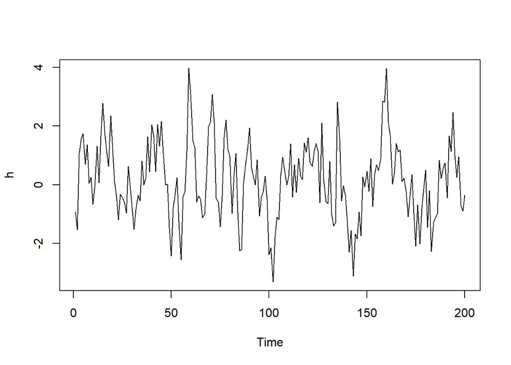

```r
h <- arima.sim(model = list(ar = 0.6), n = 200, innov = rnorm(200, 0, 1))
plot(h)
```

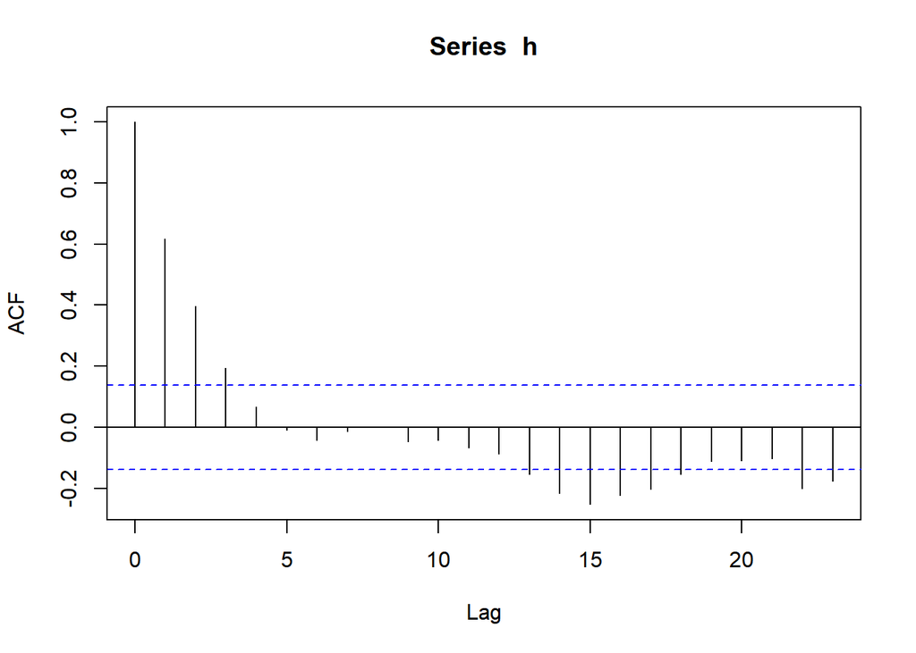

```r
acf(h)
```

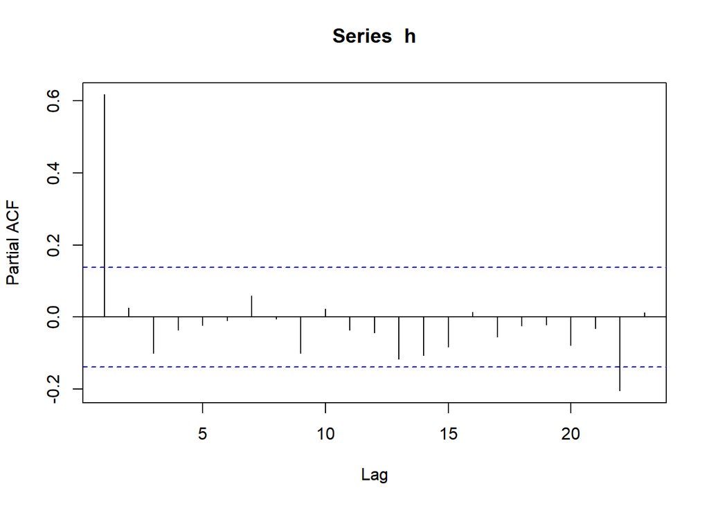

```r
pacf(h)
```

3- Utilize a série abaixo para resolver cada item.

An example of a time series that can probably be described using an additive model with a trend and no seasonality is the time series of the annual diameter of women’s skirts at the hem, from 1866 to 1911. The data is available in the file http://robjhyndman.com/tsdldata/roberts/skirts.dat (original data from Hipel and McLeod, 1994).

```r
skirts <- read.table("http://robjhyndman.com/tsdldata/roberts/skirts.dat", header = TRUE, skip = 3)
```

1. Faça a leitura da série de dados e os tratamentos necessários para considerar a mesma como uma série temporal

```r
skirts.ts<-ts(skirts, frequency=1, start=c(1866))
skirts.ts
```

```
## Time Series:
## Start = 1866
## End = 1911
## Frequency = 1
##       SKIRTS
##  [1,]    608
##  [2,]    617
##  [3,]    625
##  [4,]    636
##  [5,]    657
##  [6,]    691
##  [7,]    728
##  [8,]    784
##  [9,]    816
## [10,]    876
```

[output cut: 36 more lines]

2. Faça a decomposição da série do item (a): Sazonalidade, Tendência e Aleatória.

```r
skirts.components <- ifelse(frequency(skirts.ts)>1,
                        decompose(skirts.ts,type = c("additive", "multiplicative")),
                        print("Nao e' possivel decompor uma serie anual, para ser feita a decomposicao a serie deveria ter, no minimo, 2 periodos"))
```

```
## [1] "Nao e' possivel decompor uma serie anual, para ser feita a decomposicao a serie deveria ter, no minimo, 2 periodos"
```

```r
#plot(skirts.components)
```

3. Calcule a ACF e PACF da série e da primeira diferença

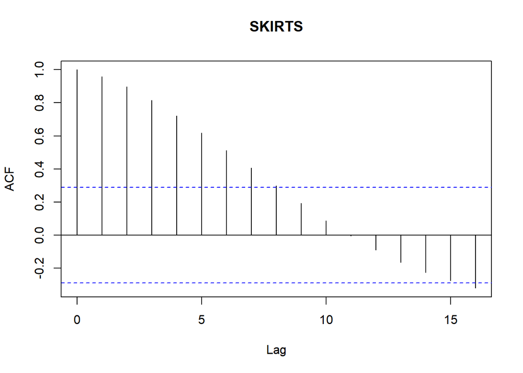

```r
acf(skirts.ts)
```

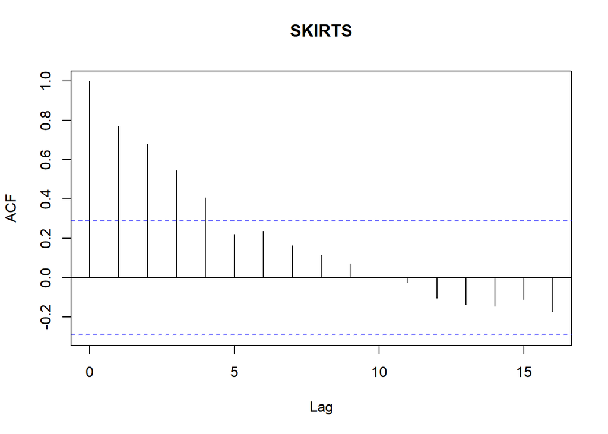

```r
acf(diff(skirts.ts))
```

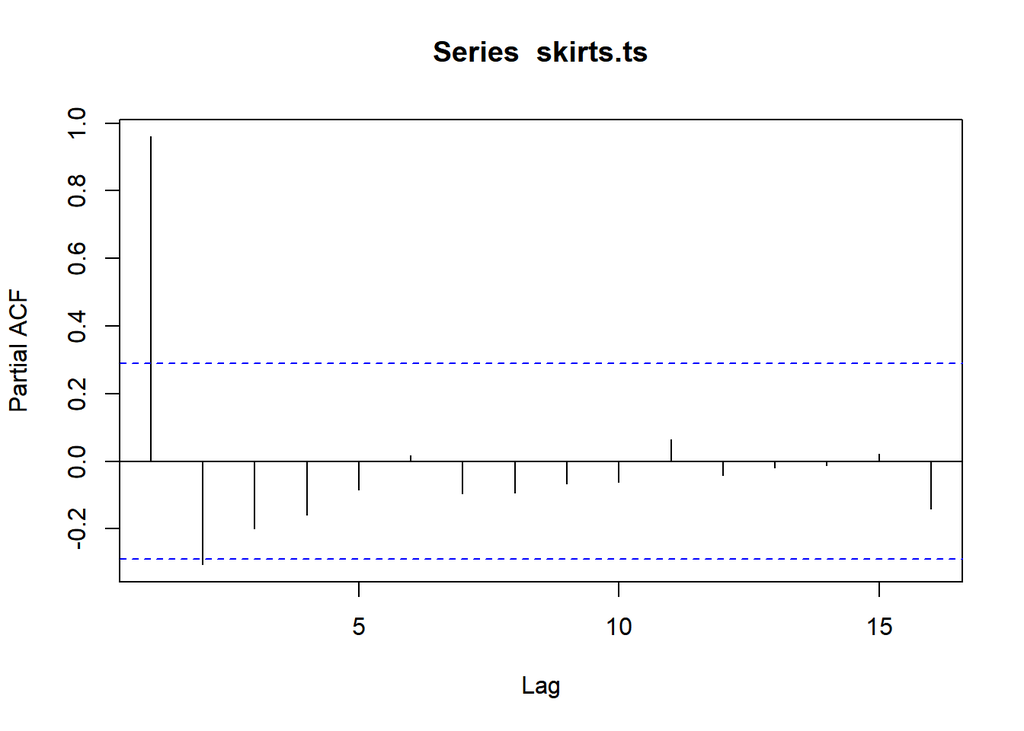

```r
pacf(skirts.ts)
```

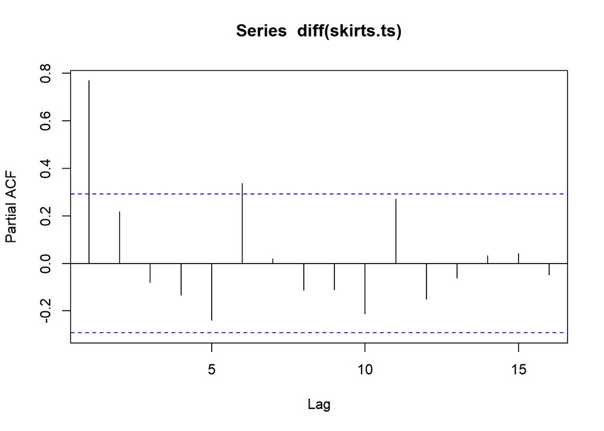

```r
pacf(diff(skirts.ts))
```

4- Usando a função arima.sim gere as seguintes simulações (300 ptos):

```r
set.seed(1234)
```

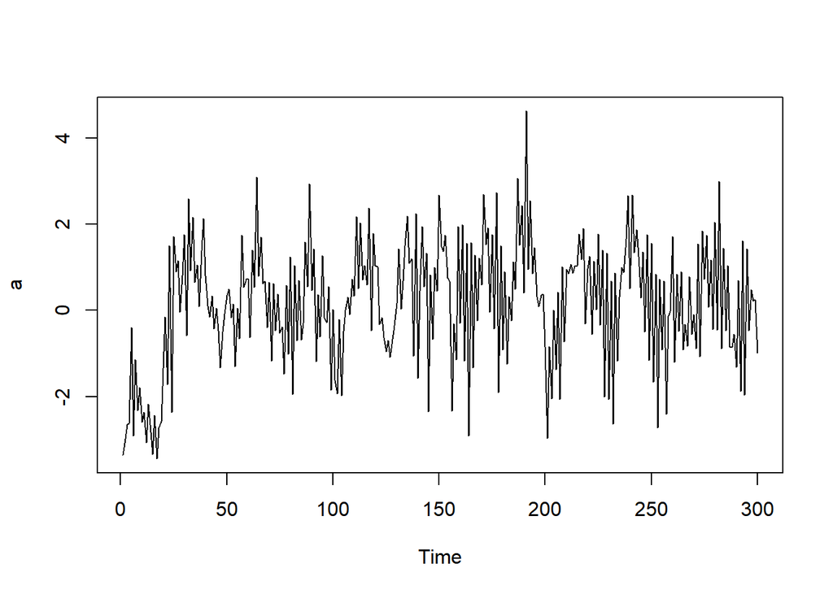

```r
a <- arima.sim(n=300,list(ar = c(0,.7)))
plot(a)
```

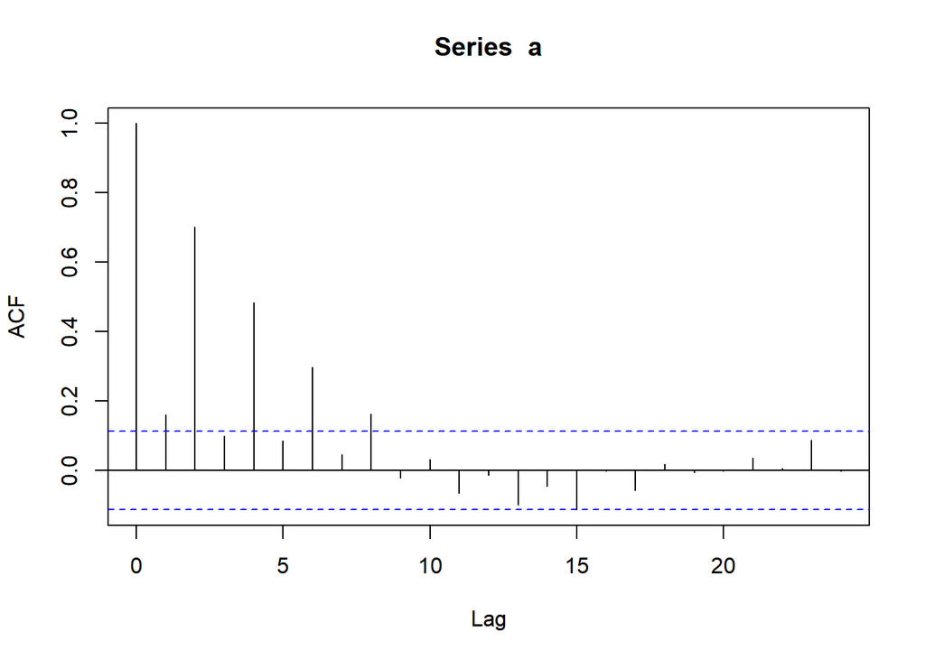

```r
acf(a)
```

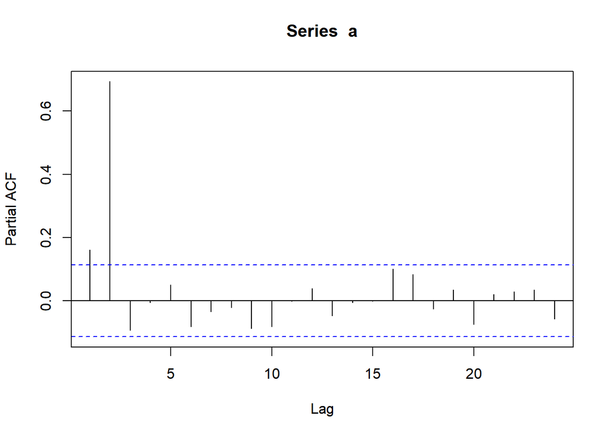

```r
pacf(a)
```

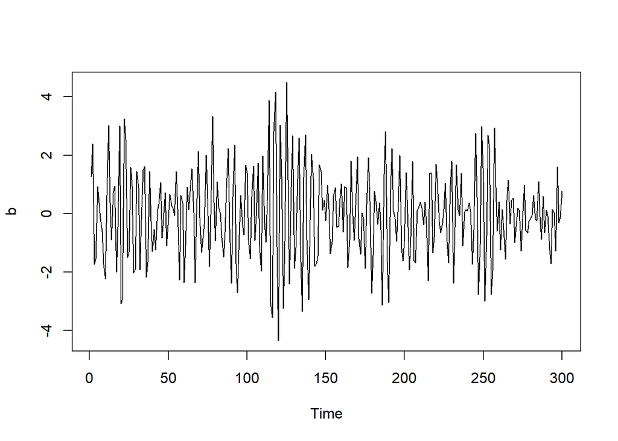

```r
b <- arima.sim(n=300,list(ar = c(0,-.7)))
plot(b)
```

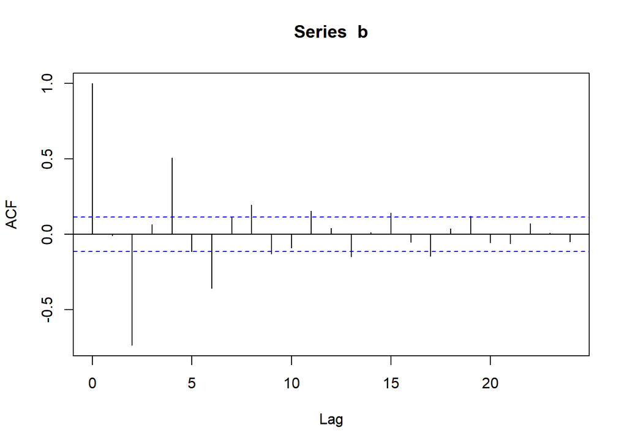

```r
acf(b)
```

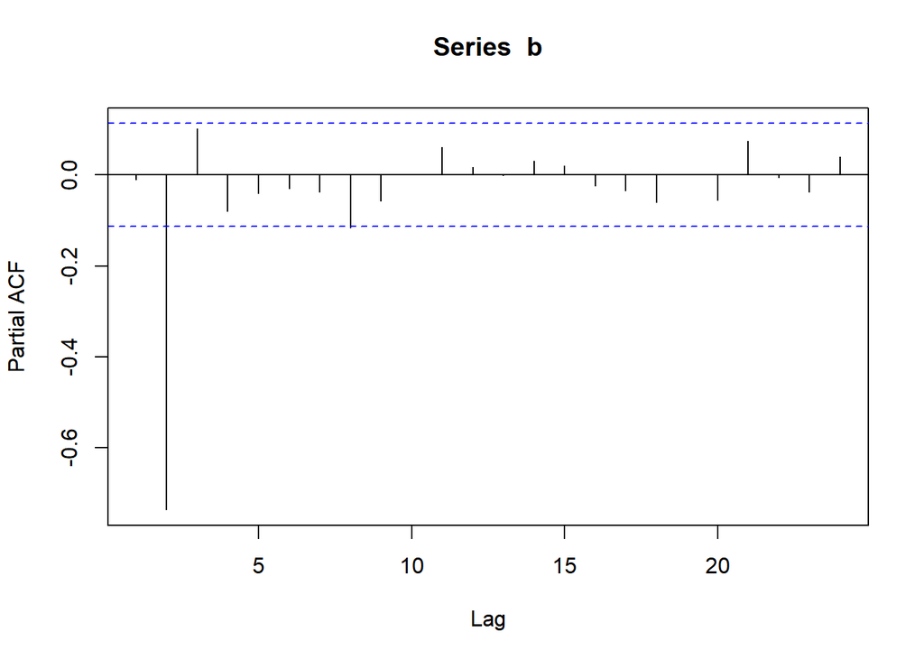

```r
pacf(b)
```

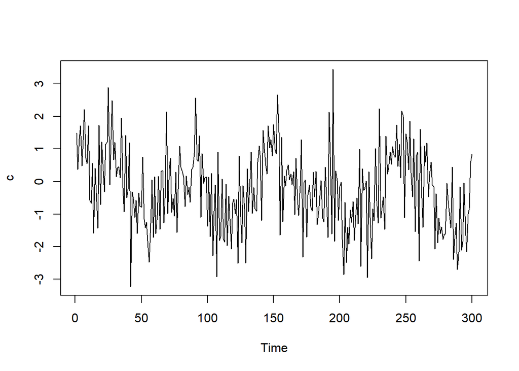

```r
c <- arima.sim(n=300,list(ar = c(0,.3,.5)))
plot(c)
```

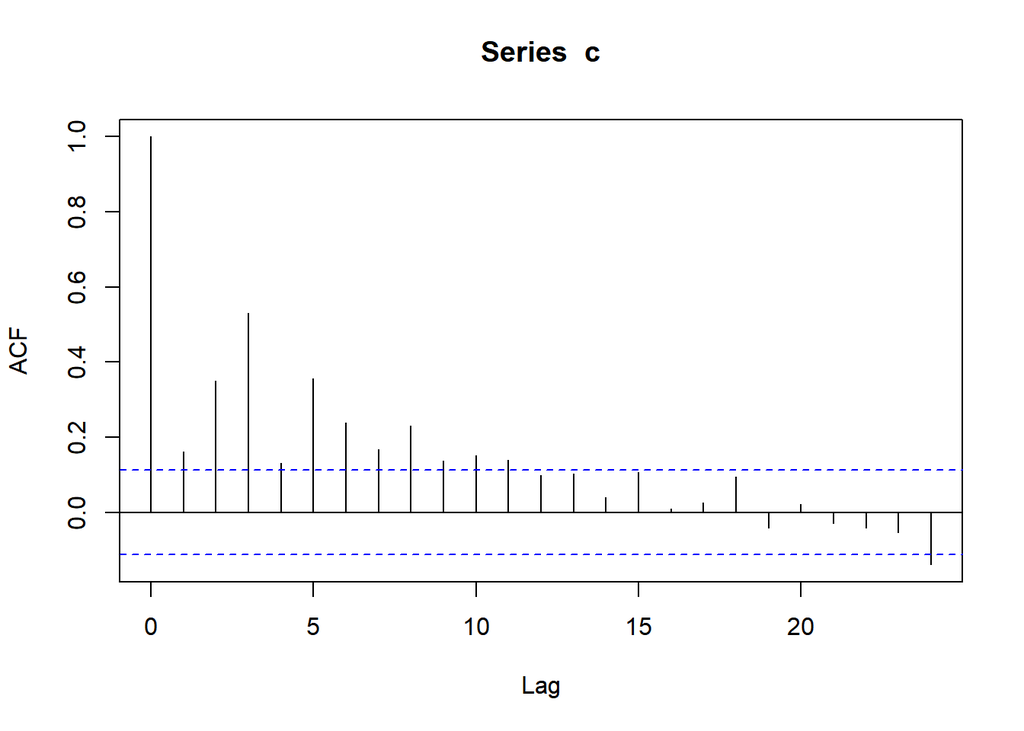

```r
acf(c)
```

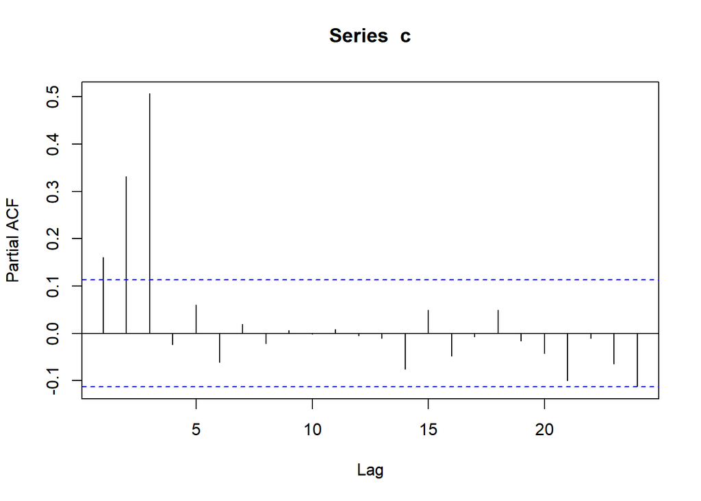

```r
pacf(c)
```

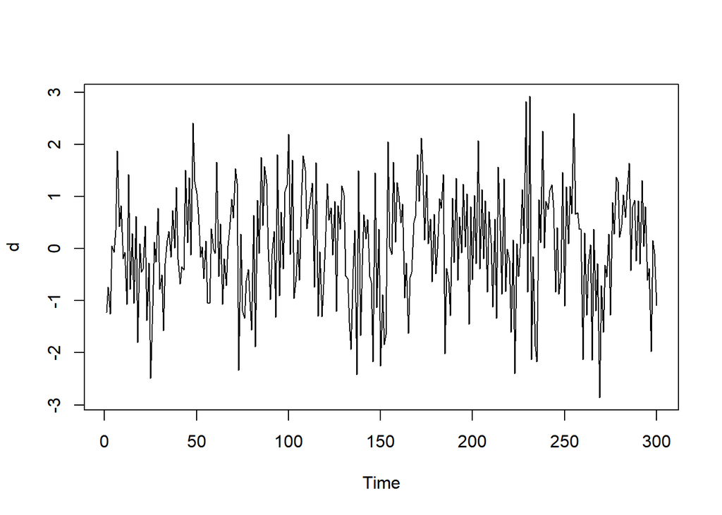

```r
d <- arima.sim(n=300,list(ma = c(0,.6)))
plot(d)
```

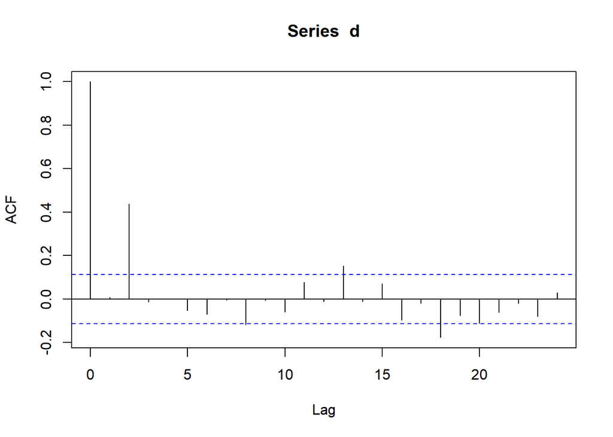

```r
acf(d)
```

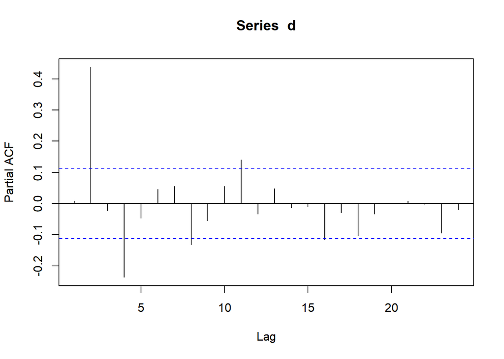

```r
pacf(d)
```

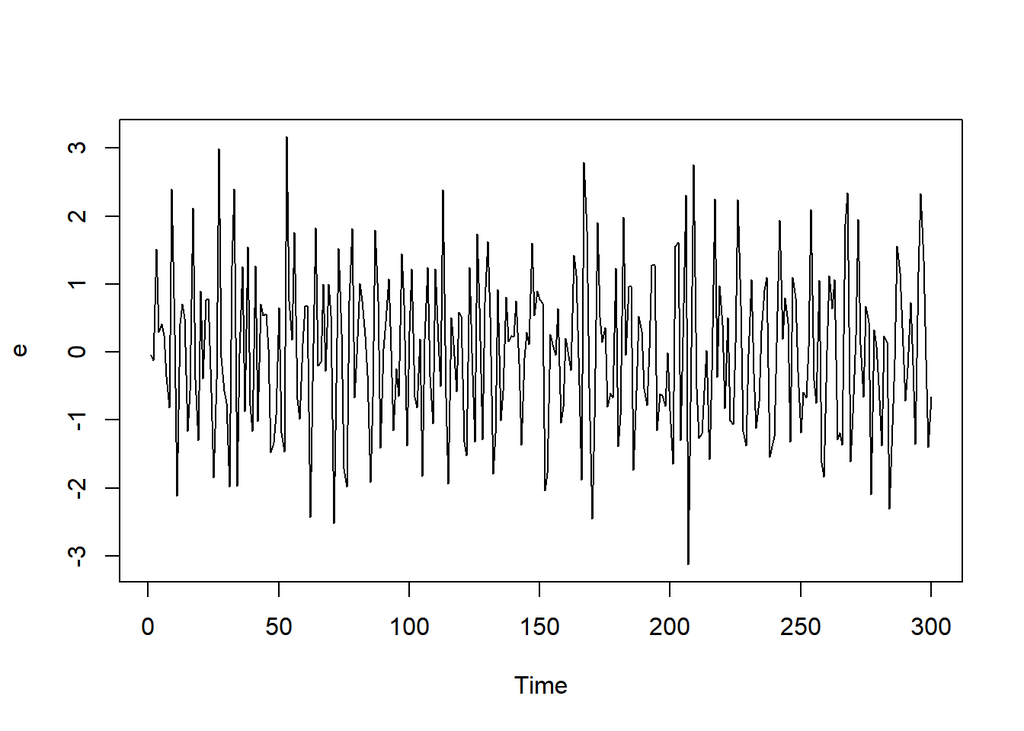

```r
e <- arima.sim(n=300,list(ma = c(0,-.6)))
plot(e)
```

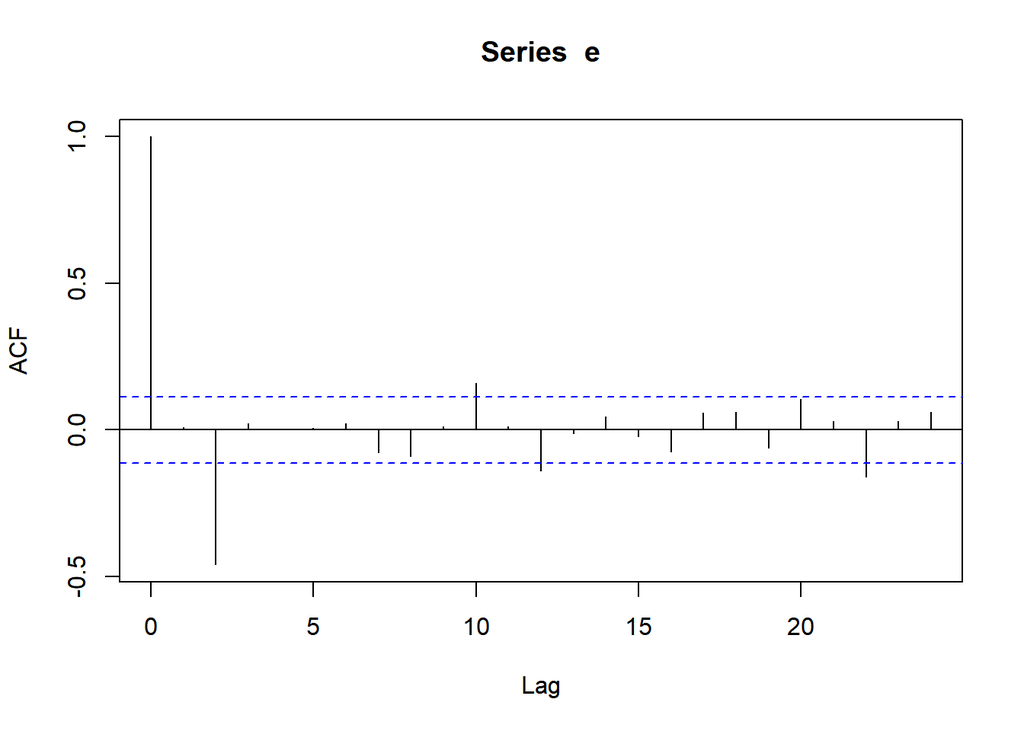

```r
acf(e)
```

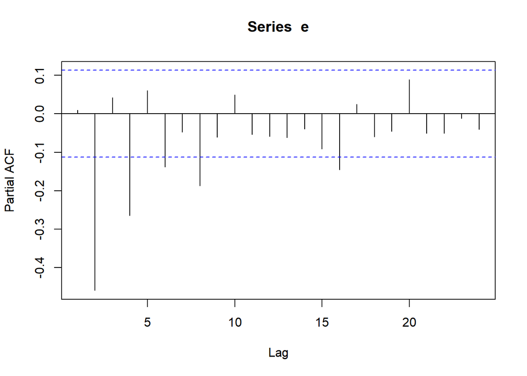

```r
pacf(e)
```

Para cada simulação, plote o gráfico da série, calcule o ACF e PACF. Usando estes resultados conclua como deve ser o comportamento da ACF de PACF de um modelo autoregressivo( AR.)

5- Obtenha a série histórica do PIB Brasil no site: http://www.bcb.gov.br/pre/portalCidadao/cadsis/series.asp?idpai=PORTALBCB Código da série: 1232

```r
PIB <- read.csv("PIB.csv", sep=";")
#View(PIB)
PIB.ts<-ts(PIB$X1232.PIB, frequency=4, start=c(1991,1))
```

1. Plote o gráfico da série usando o R

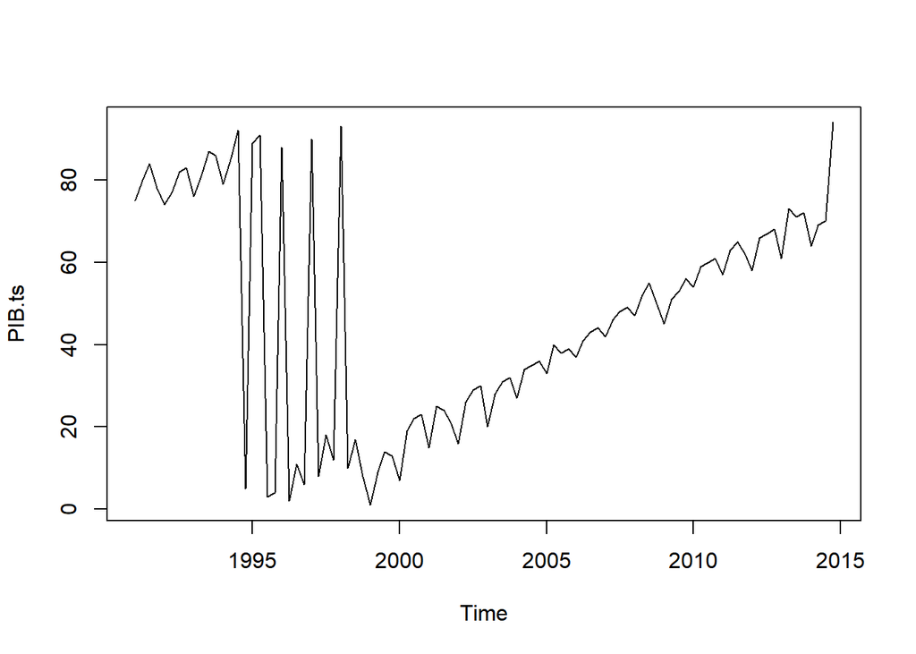

```r
plot.ts(PIB.ts)
```

2. Faça a decomposição da série em: Sazonalidade, Tendência e Aleatória.

```r
PIB.decomposto <- decompose(PIB.ts)
PIB.decomposto
```

```
## $x
##      Qtr1 Qtr2 Qtr3 Qtr4
## 1991   75   80   84   78
## 1992   74   77   82   83
## 1993   76   81   87   86
## 1994   79   85   92    5
## 1995   89   91    3    4
## 1996   88    2   11    6
## 1997   90    8   18   12
## 1998   93   10   17    8
## 1999    1    9   14   13
## 2000    7   19   22   23
## 2001   15   25   24   21
## 2002   16   26   29   30
## 2003   20   28   31   32
```

[output cut: 101 more lines]

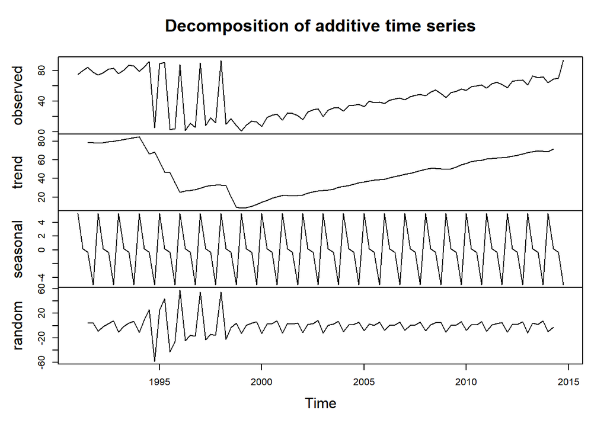

```r
plot(PIB.decomposto)
```

3. Usando o índice dos últimos 12 anos, encontre uma projeção para o PIB(índice) do próximo semestre usando um modelo AR(1). Neste caso use a série das diferenças.

Usando Predict:

```r
if(!require(forecast)) {
  install.packages("forecast")
  library(forecast)
}
PIB.dif <- diff(PIB.ts[49:96])
PIB.predict <- predict(auto.arima(PIB.dif),ahead = 1)
PIB.predict
```

```
## $pred
## Time Series:
## Start = 48
## End = 48
## Frequency = 1
## [1] -6.898466
##
## $se
## Time Series:
## Start = 48
## End = 48
## Frequency = 1
## [1] 5.194559
```

Usando Forecast:

```r
etsfit.PIB.dif <- ets(PIB.dif)
etsfit.PIB.dif
```

```
## ETS(A,N,N)
##
## Call:
##  ets(y = PIB.dif)
##
##   Smoothing parameters:
##     alpha = 1e-04
##
##   Initial states:
##     l = 1.5736
##
##   sigma:  5.4275
##
##      AIC     AICc      BIC
## 343.9129 344.4711 349.4634
```

```r
accuracy(etsfit.PIB.dif)
```

```
##                       ME     RMSE      MAE      MPE    MAPE      MASE
## Training set 0.001407463 5.310812 3.681257 59.63687 88.9061 0.6271772
##                    ACF1
## Training set -0.2199867
```

```r
fcast.PIB.dif <- forecast(etsfit.PIB.dif)
fcast.PIB.dif
```

```
##    Point Forecast     Lo 80    Hi 80     Lo 95    Hi 95
## 48        1.57364 -5.382041 8.529321 -9.064157 12.21144
## 49        1.57364 -5.382041 8.529321 -9.064157 12.21144
## 50        1.57364 -5.382041 8.529321 -9.064157 12.21144
## 51        1.57364 -5.382042 8.529321 -9.064157 12.21144
## 52        1.57364 -5.382042 8.529322 -9.064157 12.21144
## 53        1.57364 -5.382042 8.529322 -9.064157 12.21144
## 54        1.57364 -5.382042 8.529322 -9.064157 12.21144
## 55        1.57364 -5.382042 8.529322 -9.064157 12.21144
## 56        1.57364 -5.382042 8.529322 -9.064157 12.21144
## 57        1.57364 -5.382042 8.529322 -9.064157 12.21144
```

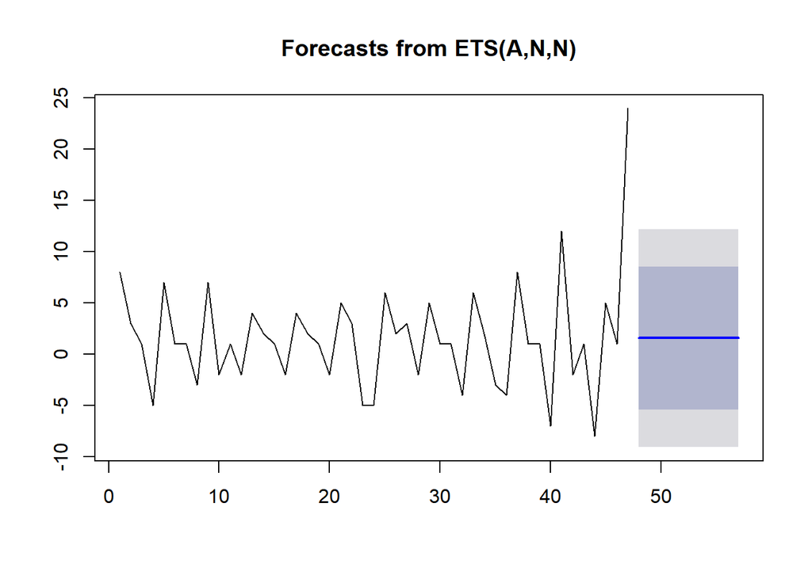

```r
plot(fcast.PIB.dif)
```

Usando ARIMA:

```r
arimafit.PIB.dif <- auto.arima(PIB.dif)
fcast.ARIMA.PIB.dif <- forecast(arimafit.PIB.dif)
fcast.ARIMA.PIB.dif
```

```
##    Point Forecast      Lo 80      Hi 80      Lo 95     Hi 95
## 48     -6.8984662 -13.555561 -0.2413712 -17.079614  3.282682
## 49      4.4612251  -2.631513 11.5539636  -6.386182 15.308633
## 50      0.2848823  -6.864703  7.4344677 -10.649465 11.219230
## 51      1.8202972  -5.336937  8.9775316  -9.125748 12.766343
## 52      1.2558084  -5.902459  8.4140760  -9.691817 12.203434
## 53      1.4633403  -5.695067  8.6217476  -9.484499 12.411179
## 54      1.3870421  -5.771384  8.5454682  -9.560826 12.334910
## 55      1.4150928  -5.743336  8.5735215  -9.532779 12.362965
## 56      1.4047801  -5.753649  8.5632091  -9.543092 12.352653
## 57      1.4085715  -5.749858  8.5670006  -9.539301 12.356444
```

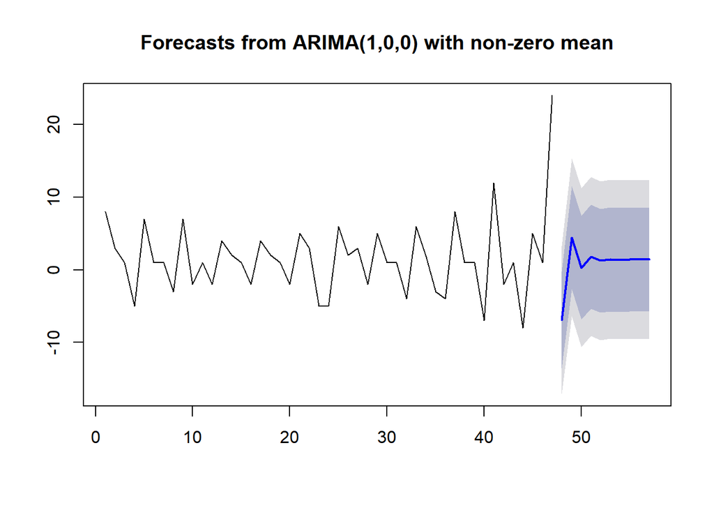

```r
plot(fcast.ARIMA.PIB.dif)
```

Usando Forecast (sem usar a diferença):

```r
etsfit.PIB.ts <- ets(PIB.ts[49:96])
etsfit.PIB.ts
```

```
## ETS(M,A,N)
##
## Call:
##  ets(y = PIB.ts[49:96])
##
##   Smoothing parameters:
##     alpha = 0.0296
##     beta  = 0.0296
##
##   Initial states:
##     l = 25.1972
##     b = 1.3539
##
##   sigma:  0.0825
##
##      AIC     AICc      BIC
## 326.5554 327.9840 335.9114
```

```r
accuracy(etsfit.PIB.ts)
```

```
##                      ME     RMSE      MAE       MPE     MAPE      MASE
## Training set 0.01216636 4.313633 2.950698 -1.043802 5.960771 0.7456065
##                     ACF1
## Training set -0.04256709
```

```r
fcast.PIB.ts <- forecast(etsfit.PIB.ts)
fcast.PIB.ts
```

```
##    Point Forecast    Lo 80    Hi 80    Lo 95     Hi 95
## 49       75.54042 67.55617 83.52466 63.32957  87.75127
## 50       76.91158 68.76863 85.05453 64.45801  89.36515
## 51       78.28274 69.96423 86.60126 65.56067  91.00482
## 52       79.65391 71.13682 88.17100 66.62814  92.67967
## 53       81.02507 72.28071 89.76944 67.65172  94.39842
## 54       82.39623 73.39078 91.40169 68.62358  96.16889
## 55       83.76740 74.46259 93.07221 69.53692  97.99787
## 56       85.13856 75.49243 94.78469 70.38608  99.89105
## 57       86.50972 76.47736 96.54209 71.16654 101.85291
## 58       87.88089 77.41520 98.34658 71.87500 103.88678
```

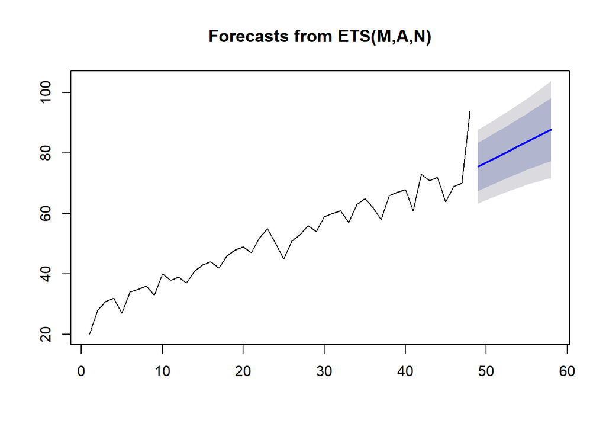

```r
plot(fcast.PIB.ts)
```

Usando ARIMA (sem usar a diferença):

```r
arimafit.PIB.ts <- auto.arima(PIB.ts[49:96])
fcast.ARIMA.PIB.ts <- forecast(arimafit.PIB.ts)
fcast.ARIMA.PIB.ts
```

```
##    Point Forecast    Lo 80     Hi 80    Lo 95     Hi 95
## 49       87.10154 80.44444  93.75863 76.92039  97.28269
## 50       91.56276 83.68634  99.43918 79.51681 103.60871
## 51       91.84764 82.45912 101.23617 77.48913 106.20615
## 52       93.66794 83.13325 104.20263 77.55652 109.77936
## 53       94.92375 83.30514 106.54236 77.15461 112.69289
## 54       96.38709 83.79469 108.97949 77.12868 115.64550
## 55       97.77413 84.27211 111.27616 77.12457 118.42370
## 56       99.18923 84.83715 113.54130 77.23963 121.13883
## 57      100.59401 85.43878 115.74923 77.41609 123.77193
## 58      102.00258 86.08492 117.92024 77.65862 126.34654
```

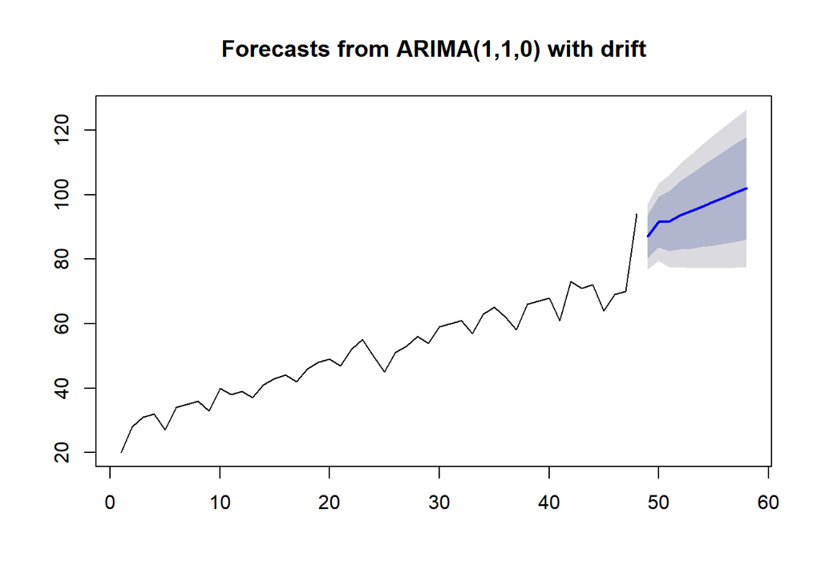

```r
plot(fcast.ARIMA.PIB.ts)
```